# Assignment 2

Dineshkumar

2024-08-19

```r
library(tinytex)
library(ISLR)
library(MASS)
```

#1. In this exercise you will create some simulated data and will fit simple linear regression models to it. Make sure to use set.seed(1) prior to starting part (a) to ensure consistent results.rnorm

#a)Using the rnorm() function, create a vector, “x”, containing 100 observations drawn from a N(0,1) distribution. This represents a feature, X.

```r
set.seed(1)
x = rnorm(100,0,1)
x
```

```
##   [1] -0.626453811  0.183643324 -0.835628612  1.595280802  0.329507772
##   [6] -0.820468384  0.487429052  0.738324705  0.575781352 -0.305388387
##  [11]  1.511781168  0.389843236 -0.621240581 -2.214699887  1.124930918
##  [16] -0.044933609 -0.016190263  0.943836211  0.821221195  0.593901321
##  [21]  0.918977372  0.782136301  0.074564983 -1.989351696  0.619825748
##  [26] -0.056128740 -0.155795507 -1.470752384 -0.478150055  0.417941560
##  [31]  1.358679552 -0.102787727  0.387671612 -0.053805041 -1.377059557
##  [36] -0.414994563 -0.394289954 -0.059313397  1.100025372  0.763175748
##  [41] -0.164523596 -0.253361680  0.696963375  0.556663199 -0.688755695
##  [46] -0.707495157  0.364581962  0.768532925 -0.112346212  0.881107726
##  [51]  0.398105880 -0.612026393  0.341119691 -1.129363096  1.433023702
##  [56]  1.980399899 -0.367221476 -1.044134626  0.569719627 -0.135054604
##  [61]  2.401617761 -0.039240003  0.689739362  0.028002159 -0.743273209
##  [66]  0.188792300 -1.804958629  1.465554862  0.153253338  2.172611670
##  [71]  0.475509529 -0.709946431  0.610726353 -0.934097632 -1.253633400
##  [76]  0.291446236 -0.443291873  0.001105352  0.074341324 -0.589520946
##  [81] -0.568668733 -0.135178615  1.178086997 -1.523566800  0.593946188
##  [86]  0.332950371  1.063099837 -0.304183924  0.370018810  0.267098791
##  [91] -0.542520031  1.207867806  1.160402616  0.700213650  1.586833455
##  [96]  0.558486426 -1.276592208 -0.573265414 -1.224612615 -0.473400636
```

#b)Using the rnorm() function, create a vector, “eps”, containing 100 observations drawn from a N(0,0.25) distribution.

```r
eps = rnorm(100,0,sqrt(0.25))
eps
```

```
##   [1] -0.310183339  0.021057937 -0.455460824  0.079014386 -0.327292322
##   [6]  0.883643635  0.358353738  0.455087115  0.192092679  0.841088040
##  [11] -0.317868227 -0.230822365  0.716141119 -0.325348177 -0.103690372
##  [16] -0.196403965 -0.159996434 -0.139556651  0.247094166 -0.088665241
##  [21] -0.252978731  0.671519413 -0.107289704 -0.089778265 -0.050095371
##  [26]  0.356333154 -0.036782202 -0.018817086 -0.340830239 -0.162135136
##  [31]  0.030080220 -0.294447243  0.265748096 -0.759197041  0.153278930
##  [36] -0.768224912 -0.150488063 -0.264139952 -0.326047390 -0.028448389
##  [41] -0.957179713  0.588291656 -0.832486218 -0.231765201 -0.557960053
##  [46] -0.375409501  1.043583273  0.008697810 -0.643150265 -0.820302767
##  [51]  0.225093551 -0.009279916 -0.159034187 -0.464681074 -0.743730155
##  [56] -0.537596148  0.500014402 -0.310633347 -0.692213424  0.934645311
##  [61]  0.212550189 -0.119323550  0.529241524  0.443211326 -0.309621524
##  [66]  1.103051232 -0.127513515 -0.712247325 -0.072199801  0.103769170
##  [71]  1.153989200  0.052901184  0.228499403 -0.038576468 -0.167000421
##  [76] -0.017363014  0.393819803  1.037622504  0.513696219  0.603954199
##  [81] -0.615661711  0.491947785  0.109962402 -0.733625015  0.260511371
##  [86] -0.079377302  0.732293656 -0.383041000 -0.215105877 -0.463054749
##  [91] -0.088551981  0.201005890 -0.365874087  0.415186584 -0.604041393
##  [96] -0.523992206  0.720578853 -0.507923733  0.205987356 -0.190538026
```

#c)Using “x” and “eps”, generate a vector “y” according to the model Y=−1+0.5X+ε.What is the length of the vector “y” ? What are the values of β0 and β1 in this linear model ?

```r
y <- -1 + 0.5*x + eps
y
```

```
##   [1] -1.62341024 -0.88712040 -1.87327513 -0.12334521 -1.16253844 -0.52659056
##   [7] -0.39793174 -0.17575053 -0.52001665 -0.31160615 -0.56197764 -1.03590075
##  [13] -0.59447917 -2.43269812 -0.54122491 -1.21887077 -1.16809157 -0.66763855
##  [19] -0.34229524 -0.79171458 -0.79349005  0.06258756 -1.07000721 -2.08445411
##  [25] -0.74018250 -0.67173122 -1.11467996 -1.75419328 -1.57990527 -0.95316436
##  [31] -0.29058000 -1.34584111 -0.54041610 -1.78609956 -1.53525085 -1.97572219
##  [37] -1.34763304 -1.29379665 -0.77603470 -0.64686051 -2.03944151 -0.53838918
##  [43] -1.48400453 -0.95343360 -1.90233790 -1.72915708  0.22587425 -0.60703573
##  [49] -1.69932337 -1.37974890 -0.57585351 -1.31529311 -0.98847434 -2.02936262
##  [55] -1.02721830 -0.54739620 -0.68359634 -1.83270066 -1.40735361 -0.13288199
##  [61]  0.41335907 -1.13894355 -0.12588879 -0.54278759 -1.68125813  0.19744738
##  [67] -2.02999283 -0.97946989 -0.99557313  0.19007500  0.39174396 -1.30207203
##  [73] -0.46613742 -1.50562528 -1.79381712 -0.87163990 -0.82782613  0.03817518
##  [79] -0.44913312 -0.69080627 -1.89999608 -0.57564152 -0.30099410 -2.49540841
##  [85] -0.44251553 -0.91290212  0.26384357 -1.53513296 -1.03009647 -1.32950535
##  [91] -1.35981200 -0.19506021 -0.78567278 -0.23470659 -0.81062467 -1.24474899
##  [97] -0.91771725 -1.79455644 -1.40631895 -1.42723834
```

#d)d. Create a scatterplot displaying the relationship between “x” and “y”. Comment on what you observe.

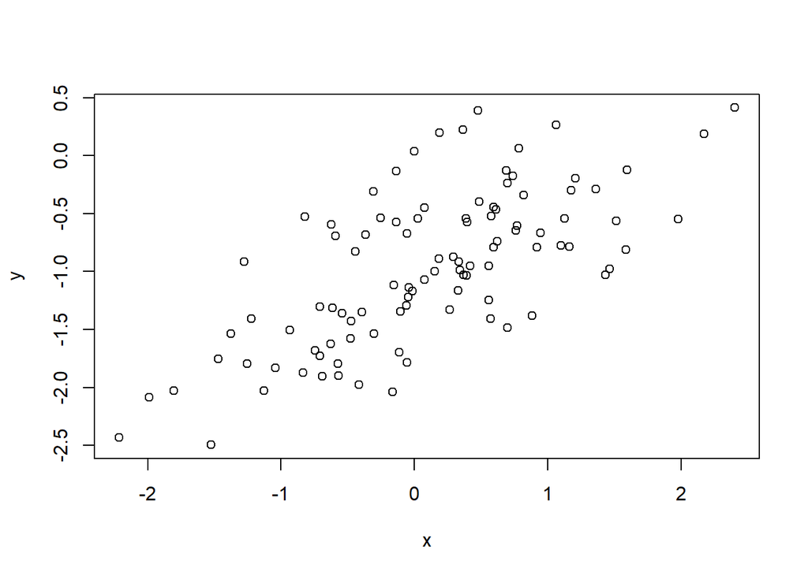

```r
plot(x,y)
```

#e)Fit a least squares linear model to predict “y” using “x”. Comment on the model obtained. How do β^0 and β^1 compare to β0 and β1 ?

```r
fit = lm(y~x)
summary(fit)
```

```
##
## Call:
## lm(formula = y ~ x)
##
## Residuals:
##      Min       1Q   Median       3Q      Max
## -0.93842 -0.30688 -0.06975  0.26970  1.17309
##
## Coefficients:
##             Estimate Std. Error t value Pr(>|t|)
## (Intercept) -1.01885    0.04849 -21.010  < 2e-16 ***
## x            0.49947    0.05386   9.273 4.58e-15 ***
## ---
## Signif. codes:  0 '***' 0.001 '**' 0.01 '*' 0.05 '.' 0.1 ' ' 1
##
## Residual standard error: 0.4814 on 98 degrees of freedom
## Multiple R-squared:  0.4674, Adjusted R-squared:  0.4619
## F-statistic: 85.99 on 1 and 98 DF,  p-value: 4.583e-15
```

#f)Display the least squares line on the scatterplot obtained in (d). Draw the population regression line on the plot, in a different color. Use the legend() function to create an appropriate legend.

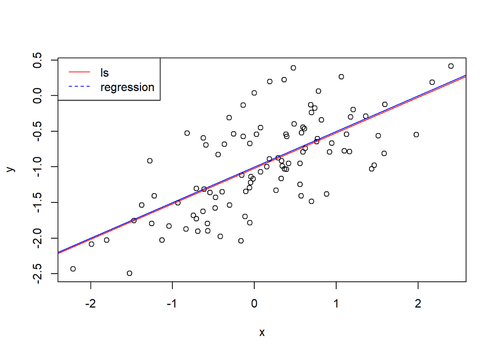

```r
plot(x,y)
abline(coef = c(-1,0.5),col = "blue")
abline(fit,col="red")
legend("topleft",c("ls","regression"),col=c("red","blue"),lty = c(1,2))
```

#2)This problem involves the “Boston” data set, which we saw in the lab for this chapter. We will now try to predict per capita crime rate using the other variables in this data set. In other words, per capita crime rate is the response, and the other variables are the predictors.

#a)For each predictor, fit a simple linear regression model to predict the response. Describe your results. In which of the models is there a statistically significant association between the predictor and the response ? Create some plots to back up your assertions.

```r
attach(Boston)
names(Boston)
```

```
##  [1] "crim"    "zn"      "indus"   "chas"    "nox"     "rm"      "age"
##  [8] "dis"     "rad"     "tax"     "ptratio" "black"   "lstat"   "medv"
```

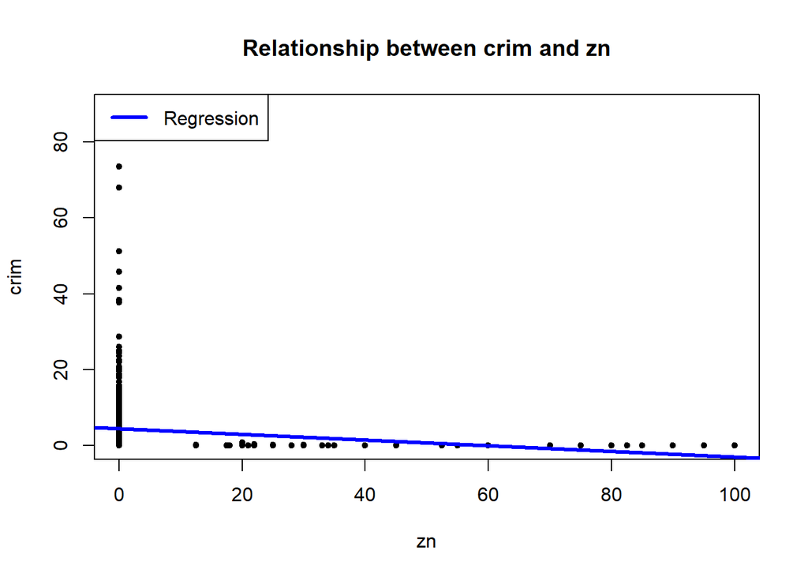

```r
# Assuming zn and crim are defined as numeric vectors
plot(zn, crim, pch = 20, main = "Relationship between crim and zn")
linear_fit <- lm(crim ~ zn)  # Fit linear model
abline(linear_fit, col = "blue", lwd = 3)
legend("topleft", legend = c("Regression"), col = "blue", lty = 1, lwd = 3)
```

```r
fit2 = lm(crim ~ indus )
summary(fit2)
```

```
##
## Call:
## lm(formula = crim ~ indus)
##
## Residuals:
##     Min      1Q  Median      3Q     Max
## -11.972  -2.698  -0.736   0.712  81.813
##
## Coefficients:
##             Estimate Std. Error t value Pr(>|t|)
## (Intercept) -2.06374    0.66723  -3.093  0.00209 **
## indus        0.50978    0.05102   9.991  < 2e-16 ***
## ---
## Signif. codes:  0 '***' 0.001 '**' 0.01 '*' 0.05 '.' 0.1 ' ' 1
##
## Residual standard error: 7.866 on 504 degrees of freedom
## Multiple R-squared:  0.1653, Adjusted R-squared:  0.1637
## F-statistic: 99.82 on 1 and 504 DF,  p-value: < 2.2e-16
```

#b)Fit a multiple regression model to predict the response using all of the predictors. Describe your results. For which predictors can we reject the null hypothesis H0:βj=0 ?

```r
multiplemodel_fit <- lm(crim ~.,data = Boston)
summary(multiplemodel_fit)
```

```
##
## Call:
## lm(formula = crim ~ ., data = Boston)
##
## Residuals:
##    Min     1Q Median     3Q    Max
## -9.924 -2.120 -0.353  1.019 75.051
##
## Coefficients:
##               Estimate Std. Error t value Pr(>|t|)
## (Intercept)  17.033228   7.234903   2.354 0.018949 *
## zn            0.044855   0.018734   2.394 0.017025 *
## indus        -0.063855   0.083407  -0.766 0.444294
## chas         -0.749134   1.180147  -0.635 0.525867
## nox         -10.313535   5.275536  -1.955 0.051152 .
## rm            0.430131   0.612830   0.702 0.483089
## age           0.001452   0.017925   0.081 0.935488
## dis          -0.987176   0.281817  -3.503 0.000502 ***
## rad           0.588209   0.088049   6.680 6.46e-11 ***
## tax          -0.003780   0.005156  -0.733 0.463793
## ptratio      -0.271081   0.186450  -1.454 0.146611
## black        -0.007538   0.003673  -2.052 0.040702 *
## lstat         0.126211   0.075725   1.667 0.096208 .
## medv         -0.198887   0.060516  -3.287 0.001087 **
## ---
## Signif. codes:  0 '***' 0.001 '**' 0.01 '*' 0.05 '.' 0.1 ' ' 1
##
## Residual standard error: 6.439 on 492 degrees of freedom
## Multiple R-squared:  0.454,  Adjusted R-squared:  0.4396
## F-statistic: 31.47 on 13 and 492 DF,  p-value: < 2.2e-16
```